# Diagnostics & Calibration

## Calibration Diagnostics

### PIT Histogram

If predictions are perfectly calibrated, PIT values follow Uniform(0, 1). A U-shaped histogram means intervals are too narrow; a hump means too wide.

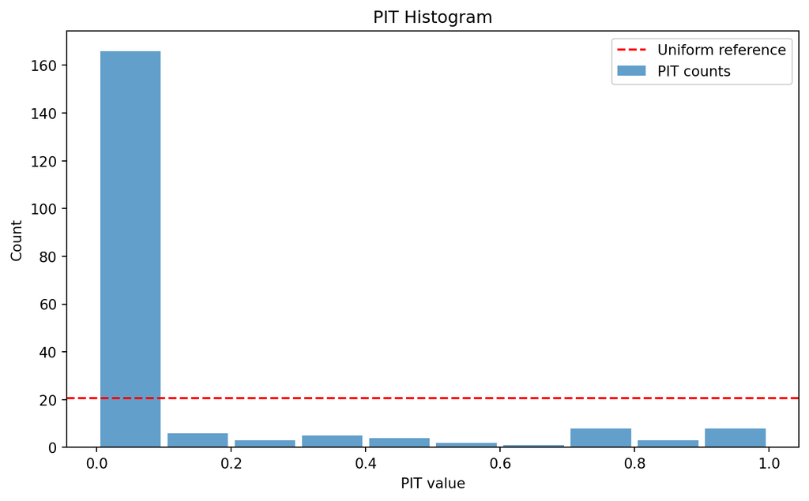

```python
pred.plot_pit(y_true)
plt.show()
```

### Calibration Curve (Reliability Diagram)

Compares expected (nominal) coverage to observed (empirical) coverage:

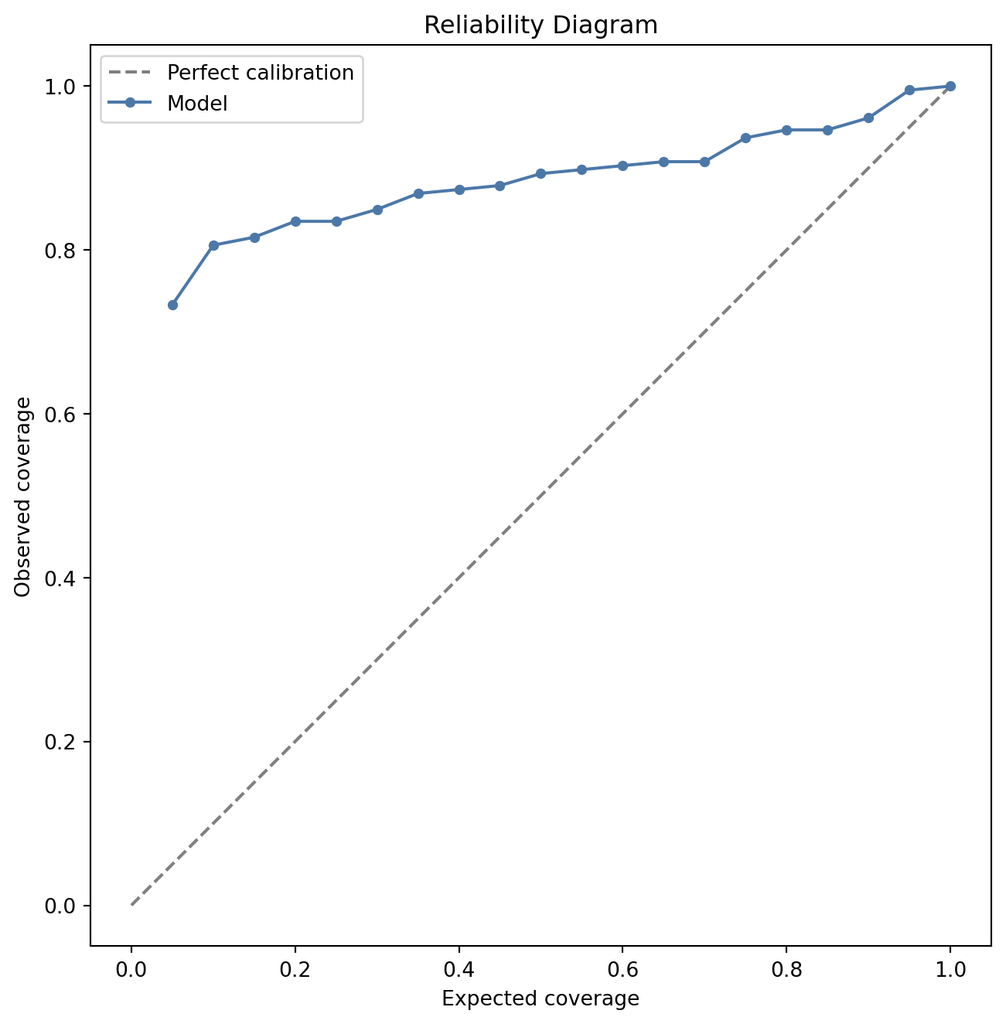

```python
cal = pred.calibration_curve(y_true, n_bins=20)
expected = cal["expected_coverage"].to_numpy()
observed = cal["observed_coverage"].to_numpy()

fig, ax = plt.subplots(figsize=(7, 7))
ax.plot([0, 1], [0, 1], "k--", alpha=0.5, label="Perfect calibration")
ax.plot(expected, observed, "o-", color="#4C78A8", markersize=4, label="Model")
ax.set_xlabel("Expected coverage")
ax.set_ylabel("Observed coverage")
ax.set_title("Reliability Diagram")
ax.legend()
ax.set_aspect("equal")
plt.tight_layout()
plt.show()
```

### Calibration Report

```python
report = model.calibration_report(test_df, target="strength")
print(report)
```

```
shape: (3, 5)
┌──────────┬────────────────────┬───────────────────┬───────────┬───────────────┐
│ quantile ┆ requested_coverage ┆ achieved_coverage ┆ sharpness ┆ winkler_score │
│ ---      ┆ ---                ┆ ---               ┆ ---       ┆ ---           │
│ f64      ┆ f64                ┆ f64               ┆ f64       ┆ f64           │
╞══════════╪════════════════════╪═══════════════════╪═══════════╪═══════════════╡
│ 0.8      ┆ 0.8                ┆ 0.15534           ┆ 13.048938 ┆ 110.257265    │
│ 0.9      ┆ 0.9                ┆ 0.262136          ┆ 22.298111 ┆ 187.615263    │
│ 0.95     ┆ 0.95               ┆ 0.262136          ┆ 22.298111 ┆ 352.932416    │
└──────────┴────────────────────┴───────────────────┴───────────┴───────────────┘
```

## Uncertainty Drivers

Which features are most associated with high prediction uncertainty?

```python
if hasattr(model, "uncertainty_drivers_") and model.uncertainty_drivers_ is not None:
    drivers = model.uncertainty_drivers_
else:
    y_pred = pred.median().to_numpy()
    residuals = y_true.to_numpy() - y_pred
    feature_cols = [c for c in test_df.columns if c != "strength"]
    drivers = compute_uncertainty_drivers(residuals, test_df.select(feature_cols))

drivers
```

shape: (6, 3)

| feature str | residual_correlation f64 | p_value f64 |
| --- | --- | --- |
| "cement" | 0.514475 | 1.1498e-9 |
| "coarseagg" | 0.376314 | 0.000018 |
| "age" | 0.172343 | 0.05663 |
| "slag" | -0.143817 | 0.112517 |
| "fineagg" | -0.5079 | 2.0185e-9 |
| "water" | -0.516881 | 9.3304e-10 |

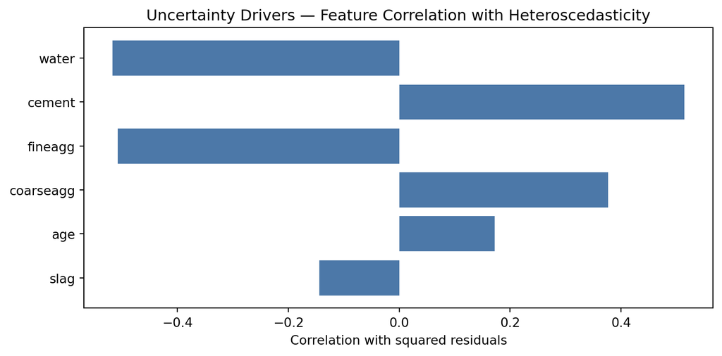

```python
feat_names = drivers["feature"].to_numpy()
correlations = drivers["residual_correlation"].to_numpy()
abs_corr = np.abs(correlations)
sort_idx = np.argsort(abs_corr)[::-1]

fig, ax = plt.subplots(figsize=(8, 4))
ax.barh(feat_names[sort_idx], correlations[sort_idx], color="#4C78A8")
ax.set_xlabel("Correlation with squared residuals")
ax.set_title("Uncertainty Drivers — Feature Correlation with Heteroscedasticity")
ax.invert_yaxis()
plt.tight_layout()
plt.show()
```

## Recalibration

`RecalibratedModel` wraps a fitted model with isotonic regression (Kuleshov et al., 2018) to learn a monotone mapping from predicted to empirical coverage.

We use a separate calibration split:

```python
plan_3way = select_validation_plan(df, task_type="tabular")
train_all, holdout = plan_3way.outer_split

plan_inner = select_validation_plan(train_all, task_type="tabular")
train_sub, calib_sub = plan_inner.outer_split

model_base = ConformalRegressor(
    base_model=GradientBoostingRegressor(random_state=42),
    coverage_target=0.9,
)
model_base.fit(train_sub, target="strength")
```

```
<uncertainty_flow.wrappers.conformal.ConformalRegressor at 0x12990c1d0>
```

```python
recal = RecalibratedModel(model=model_base)
recal.fit(calib_sub, target="strength")
pred_recal = recal.predict(holdout)
y_hold = holdout["strength"]
```

### Before vs After

```python
pred_before = model_base.predict(holdout)
int_before = pred_before.interval(0.9)
int_after = pred_recal.interval(0.9)

print("Before Recalibration:")
print(f"  Coverage: {coverage_score(y_hold, int_before['lower'], int_before['upper']):.4f}")
print(f"  Winkler:  {winkler_score(y_hold, int_before['lower'], int_before['upper'], 0.9):.2f}")

print("After Recalibration:")
print(f"  Coverage: {coverage_score(y_hold, int_after['lower'], int_after['upper']):.4f}")
print(f"  Winkler:  {winkler_score(y_hold, int_after['lower'], int_after['upper'], 0.9):.2f}")
```

```
Before Recalibration:
  Coverage: 0.7427
  Winkler:  54.35
After Recalibration:
  Coverage: 0.6117
  Winkler:  61.15
```

### PIT Comparison

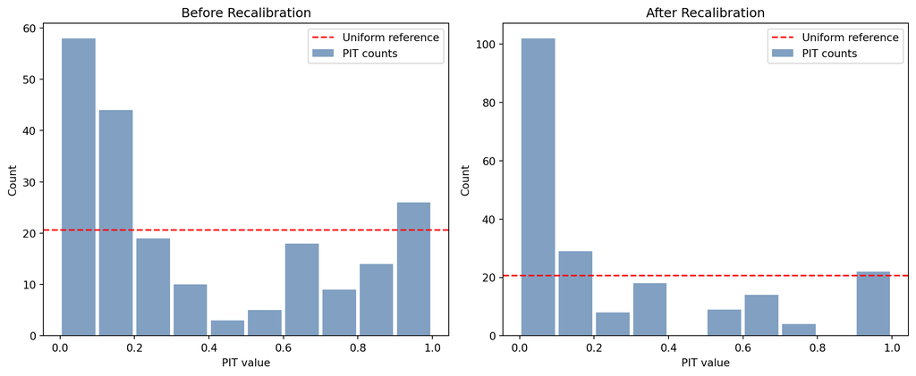

```python
fig, axes = plt.subplots(1, 2, figsize=(12, 5))

for ax, p, title in [
    (axes[0], pred_before, "Before Recalibration"),
    (axes[1], pred_recal, "After Recalibration"),
]:
    hist = p.pit_histogram(y_hold, n_bins=10)
    centers = hist["bin_center"].to_numpy()
    counts = hist["count"].to_numpy()
    expected = hist["expected"].to_numpy()
    width = centers[1] - centers[0] if len(centers) > 1 else 0.1
    ax.bar(centers, counts, width=width * 0.9, alpha=0.7, color="#4C78A8", label="PIT counts")
    ax.axhline(y=expected[0], color="red", linestyle="--", label="Uniform reference")
    ax.set_xlabel("PIT value")
    ax.set_ylabel("Count")
    ax.set_title(title)
    ax.legend()

plt.tight_layout()
plt.show()
```

## SHAP: What Drives Interval Width?

```python
from uncertainty_flow.calibration import uncertainty_shap

feature_cols = [c for c in test_df.columns if c != "strength"]
X_test = test_df.select(feature_cols)

shap_df = uncertainty_shap(model, X_test.head(50), background=X_test.head(20))
shap_df.sort("interval_width_contribution", descending=True)
```

[output not shown]

```python
if shap_df.height > 0:
    sorted_df = shap_df.sort("interval_width_contribution", descending=True)
    fig, ax = plt.subplots(figsize=(8, 4))
    ax.barh(
        sorted_df["feature"].to_numpy(),
        sorted_df["interval_width_contribution"].to_numpy(),
        color="#E45756",
    )
    ax.set_xlabel("Interval width contribution (mean |SHAP upper - SHAP lower|)")
    ax.set_title("What Drives Prediction Interval Width?")
    ax.invert_yaxis()
    plt.tight_layout()
    plt.show()
```

[output not shown]

## Key Takeaways

[output not shown]